# QAA

Logan Wallace

2022-08-31

# Part 1 – Read quality and score distributions

### 3_2B_control_S3_L008_R1_001

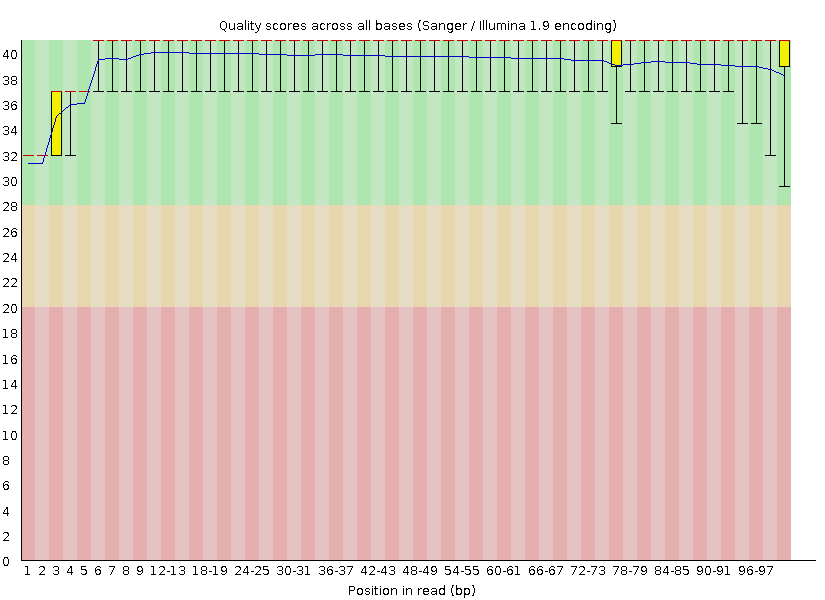

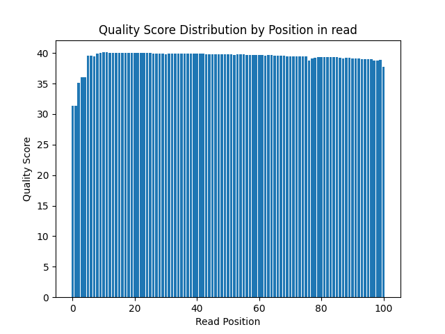

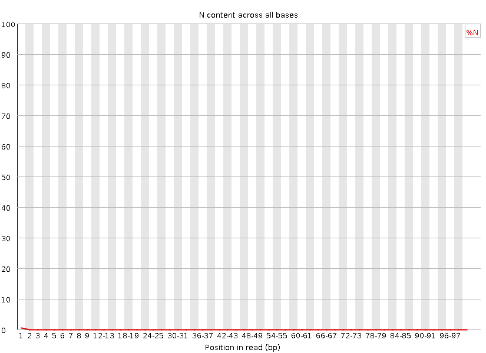

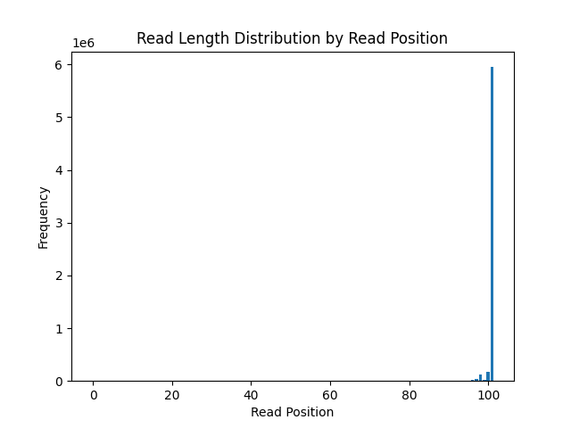

Figure 1. *Control Read 1. A. Quality score distribution.* *B. Quality score distribution C. Number of ’N’s called* *across the read. D. Read length distribution.*

### 3_2B_control_S3_L008_R2_001

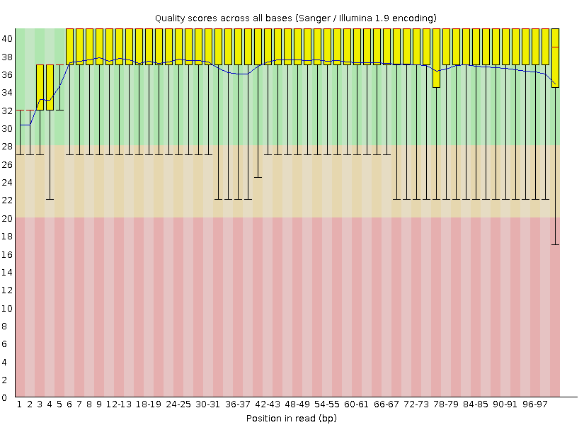

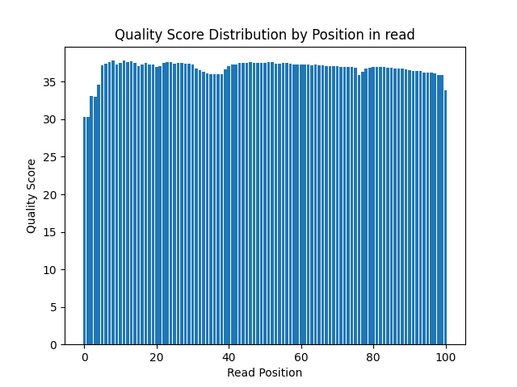

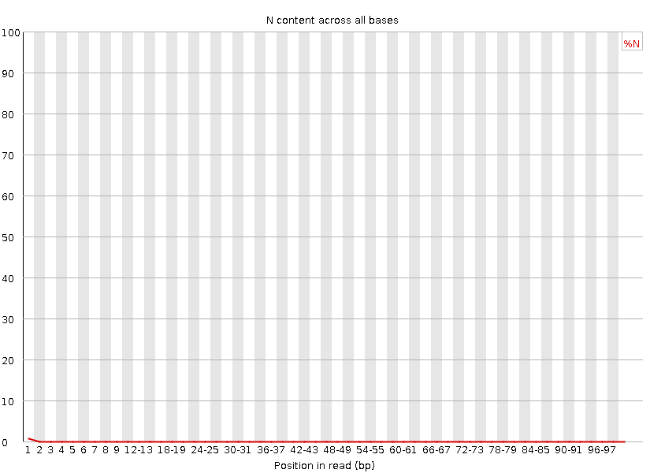

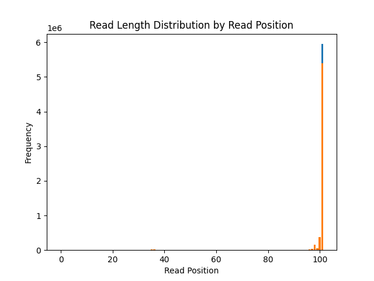

Figure 2. *Control Read 2. A. Quality score distribution.* *B. Quality score distribution C. Number of ’N’s called* *across the read. D. Read length distribution.*

### 17_3E_fox_S13_L008_R1_001

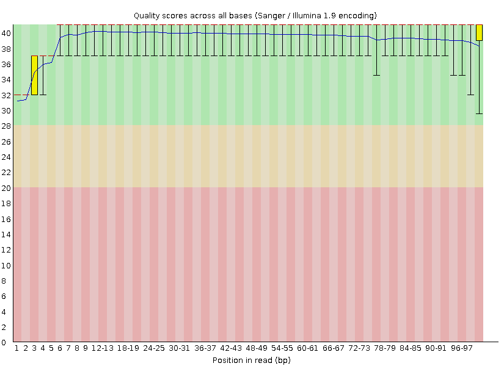

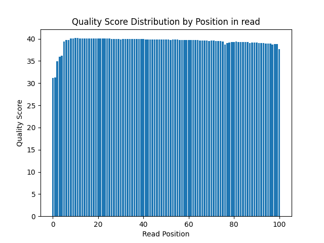

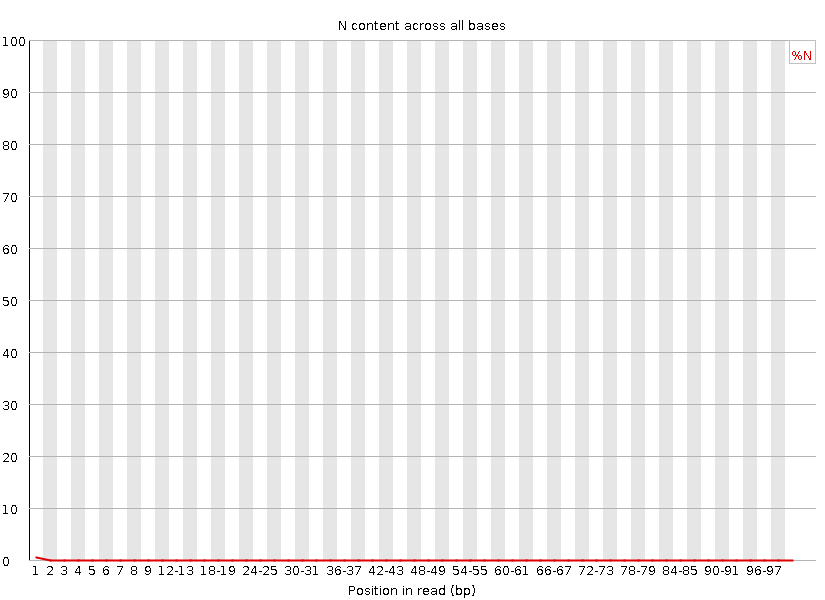

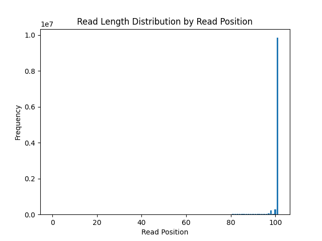

Figure 3. *Fox Read 1. A. Quality score distribution.* *B. Quality score distribution C. Number of ’N’s called* *across the read. D. Read length distribution.*

### 17_3E_fox_S13_L008_R2_001

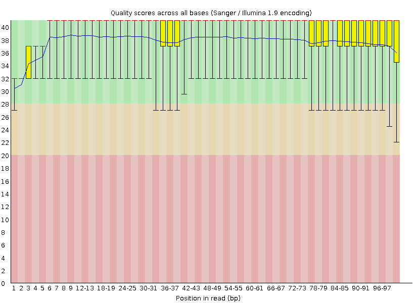

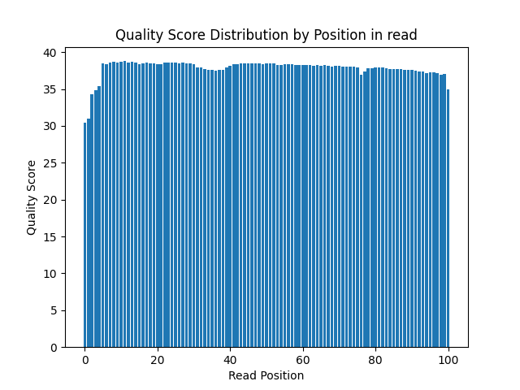

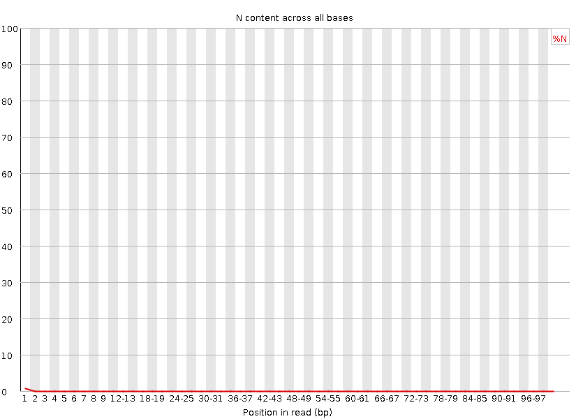

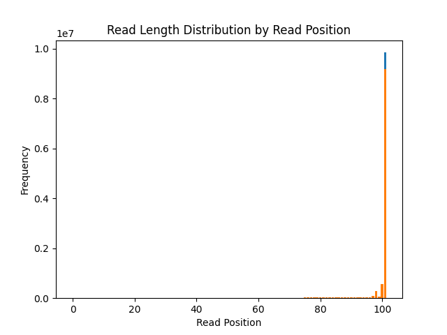

Figure 4. *Fox Read 2. A. Quality score distribution.* *B. Quality score distribution C. Number of ’N’s called* *across the read. D. Read length distribution.*

### Are the plots of N’s per base consistent with they other data?

Yes, we see that the highest frequency of N’s called are all within the first several bases of the run and this is consistent with the lowest q-scores for each run.

### Comparison of output from our script and fastQC

First, when comparing the results between my output and the output from fastQC they are very similar! We see drops in the Q-score in identical base pair positions and the scores themselves are near identical. Second, the runtime did significantly differ. My script took several minutes to run and the fastQC took only moments. I don’t have any insight into how the actual code differs, however fastQC was written by a team of experienced authors and my code was written by a masters student with minimal experience under a time constraint.

### How is the overall quality of the two libraries

Overall, the quality of the libraries seem quite good with average q-scores well above 30. 3_2B_control_S3_L008_R2_001, seems to have the lowest average quality scores.

# Part 2 – Adaptor Trimming Comparison

### 5. What proportion of reads (both R1 and R2) were trimmed?

### Reads Trimmed

| stranded arg | 3_2B_control | 17_3E_fox_S13 |
| --- | --- | --- |
| Total Pairs | 6,873,509 | 11,784,410 |
| Read 1 | 219,477 (3.2%) | 1,024,588 (8.7%) |
| Read 2 | 268,119 (3.9%) | 1,104,503 (9.4%) |

Table 1. *Table showing data from trimmomatic.* *Number of reads trimmed total and from each of* *read one and read two.*

*UNIX SKILLZ* $ zcat 3_2B_control_S3_L008_R1_001.fastq.gz | grep ‘AGATCGGAAGAGCACACGTCTGAACTCCAGTCA’ | wc -l 7659 $ zcat 3_2B_control_S3_L008_R1_001.fastq.gz | grep ‘AGATCGGAAGAGCGTCGTGTAGGGAAAGAGTGT’ | wc -l 0 Explaining the above, I ran a grep for the adapter sequences in question for each of the files (Read1 and Read2) for both the ‘control’ and ‘fox’ datasets. Above you’ll see, as expected, we only observed the R1 adapters within the R1 reads vice versa for R2.

### 7. Read length distribution for R1 and R2.

# Part 3 – Alignment and Strand Specificity

### 11. Demonstrate convincingly whether or not the data are from stranded libraries.

*More Unix skillz* $ cat htseq_count_control_rev | grep ^‘ENSMUSG’ | cut -f 2 | paste -sd+ | bc

#### HTSEQ - Read Counts

| stranded arg | 3_2B_control | 17_3E_fox_S13 |
| --- | --- | --- |
| YES | 245,058 | 5,260,739 |
| REVERSE | 443,307 | 8,952,669 |

Table 2. *The above table shows the read counts mapped for each* *dataset as counted by htseq-count using the -s argument.* *Does the read map to the same or a different strand?*